# gapminder data wrangling and visualization

# Load libraries

```r
library(tidyverse)
```

# Read in data

```r
gm <- read_csv("gapminder.csv")
```

# filter() the dataset

There are many ways to filter data. To filter data, we use “logical operators” within the filter() function.

1. `==` Which means “Is exactly equal to”
2. `!=` Which means “Is NOT equal to”
3. `>` Which means “Is greater than”
4. `<` Which means “Is less than”
5. `>=` Which means “Is greater than OR equal to”
6. `<=` Which means “Is less than OR equal to”
7. `is.na()` Which means “Contains an NA value”.
8. `!is.na()` Which means “Does NOT contain an NA value”
9. `%%` - is called a “modulo”, which means “Has a remainder of” (It’s not used as much, but is actually very useful)

```r
#Filter to only years greater than 1970
filter1 <- filter(gm, year > 1970)

#Filter to when year is 2007 & continent is Asia. A "&" means AND!
filter2 <- filter(gm, year == 2007 & continent == "Asia")

#Filter to only include data where the continent is "Americas" OR "Europe"
filter3 <- filter(gm, continent == "Americas" | continent == "Europe")
```

# select() the dataset

We use the select function to choose columns in our dataset.

```r
#Keep only country, year, lifExp
select1 <- select(gm, country, year, lifeExp)

# Remove just one of the variables (And keep the rest)
select2 <- select(gm, -lifeExp)

#select() is also great for just rearranging variables. putting "everything()" at the end of the function tells select you want to keep all of the variables.
select3 <- select(gm, country, continent, gdpPercap, everything())
```

# mutate() the dataset

We use the mutate() function to create new variables or modify existing variables.

We can multiply variables (*)  
We can divide variables (/)  
We can add variables (+)  
We can subtract variables (-)  
We can exponentiate variables (**)

```r
#Multiply gdpPercap and population. Save it into a new variable called "gdp"
mutate1 <- mutate(gm, gdp = gdpPercap*pop)


#divide gdpPercap by 10. Save it into a new variable called gdp_10
mutate2 <- mutate(gm, gdp_10 = gdpPercap/10)
```

# arrange() the dataset

You can use arrange() to sort a dataframe

```r
#sort the dataframe by year
arrange1 <- arrange(gm, year)

#Sort two by two variables (year then lifeExp)
arrange2 <- arrange(gm, year, lifeExp)

#Sort in descending order
arrange3 <- arrange(gm, desc(year))

#combine it all
arrange4 <- arrange(gm, year, desc(lifeExp))
```

# summarize() the dataset

you can summarize the dataset in certain ways.

## Get the mean of the lifeExp variable.

```r
summarize(gm, avg_lifeExp = mean(lifeExp, na.rm = TRUE))
```

| avg_lifeExp |
| --- |
| 59.47444 |

```r
NA
```

## Get the mean of lifeExp, grouped by year

```r
#First group your variable by year
gm_by_year <- group_by(gm, year)

#Optional: Check the grouping structure of the dataframe
#group_vars(gm_by_year)

#Summarize the variable
summarize(gm_by_year, avg_lifeExp = mean(lifeExp, na.rm = TRUE), .groups = "drop")
```

| year | avg_lifeExp |
| --- | --- |
| 1952 | 49.05762 |
| 1957 | 51.50740 |
| 1962 | 53.60925 |
| 1967 | 55.67829 |
| 1972 | 57.64739 |
| 1977 | 59.57016 |
| 1982 | 61.53320 |
| 1987 | 63.21261 |
| 1992 | 64.16034 |
| 1997 | 65.01468 |

[output cut: 2 more lines]

```r
#Summarize multiple aspects by year
gm_by_year <- group_by(gm, year)
summarize(gm_by_year,
          avg_lifeExp = mean(lifeExp),
          sd_lifeExp = sd(lifeExp),
          ncount = n(), .groups = "drop")
```

| year | avg_lifeExp | sd_lifeExp | ncount |
| --- | --- | --- | --- |
| 1952 | 49.05762 | 12.22596 | 142 |
| 1957 | 51.50740 | 12.23129 | 142 |
| 1962 | 53.60925 | 12.09725 | 142 |
| 1967 | 55.67829 | 11.71886 | 142 |
| 1972 | 57.64739 | 11.38195 | 142 |
| 1977 | 59.57016 | 11.22723 | 142 |
| 1982 | 61.53320 | 10.77062 | 142 |
| 1987 | 63.21261 | 10.55629 | 142 |
| 1992 | 64.16034 | 11.22738 | 142 |
| 1997 | 65.01468 | 11.55944 | 142 |

[output cut: 2 more lines]

```r
#Ungroup the dataset
gm_by_year <- ungroup(gm_by_year)
#group_vars(gm_by_year)
```

# Using the “Pipe” operator (%>%)

You can use pipes to combine any of these functions (i.e. filter(), select()) together and make your code more readable.

# Let’s filter() & select()

```r
indo <- gm %>%
  filter(country == "Indonesia") %>%
  select(year, lifeExp, country)
```

## A bit more complex… filter(), select(), group_by, & summarize()

```r
gm %>%
  filter(continent != "Oceania") %>%
  select(year, continent, country, lifeExp) %>%
  group_by(continent, year) %>%
  summarize(avg_lifeExp = mean(lifeExp),
            sd_lifeExp = sd(lifeExp),
            ncount = n(),
            .groups = "drop")
```

| continent | year | avg_lifeExp | sd_lifeExp | ncount |
| --- | --- | --- | --- | --- |
| Africa | 1952 | 39.13550 | 5.151581 | 52 |
| Africa | 1957 | 41.26635 | 5.620123 | 52 |
| Africa | 1962 | 43.31944 | 5.875364 | 52 |
| Africa | 1967 | 45.33454 | 6.082673 | 52 |
| Africa | 1972 | 47.45094 | 6.416258 | 52 |
| Africa | 1977 | 49.58042 | 6.808197 | 52 |
| Africa | 1982 | 51.59287 | 7.375940 | 52 |
| Africa | 1987 | 53.34479 | 7.864089 | 52 |
| Africa | 1992 | 53.62958 | 9.461071 | 52 |
| Africa | 1997 | 53.59827 | 9.103387 | 52 |

[output cut: 38 more lines]

# Visualizing data with ggplot()

## There are 3 essential components to ggplot

1.) The dataset  
2.) Your aesthetics function (aes())  
3.) your geom_ layer(s)

# Create a histogram

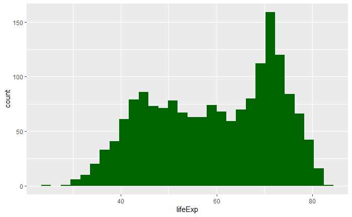

```r
ggplot(gm, aes(x = lifeExp)) +
  geom_histogram(fill = "dark green")
```

## Add a title to my histogram via labs() layer

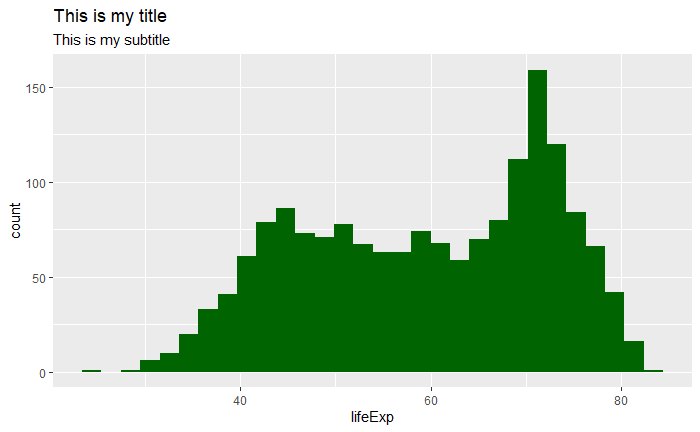

```r
ggplot(gm, aes(x = lifeExp)) +
  geom_histogram(fill = "dark green") +
  labs(title = "This is my title", subtitle = "This is my subtitle")
```

# Create a scatterplot

## A simple one

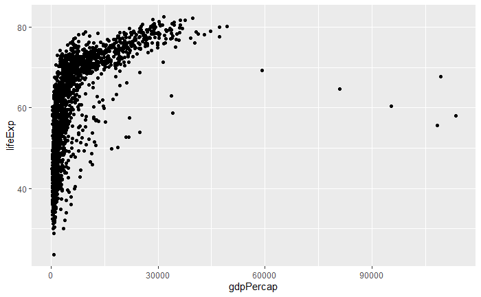

```r
ggplot(gm, aes(x = gdpPercap, y = lifeExp)) +
  geom_point()
```

## A more complex one

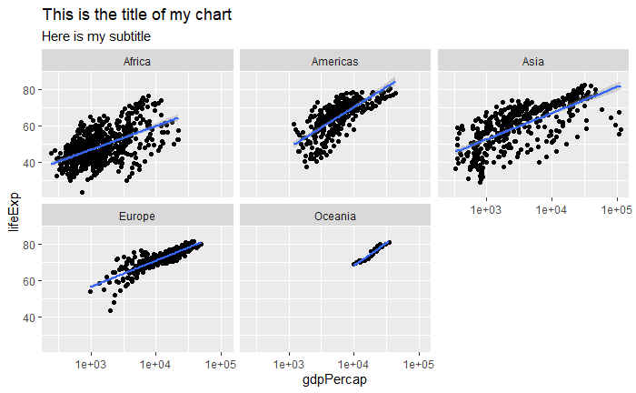

```r
ggplot(gm, aes(x = gdpPercap, y = lifeExp)) +
  geom_point() +
  geom_smooth(method = "lm") +
  facet_wrap(~ continent) +
  scale_x_log10() +
  labs(title = "This is the title of my chart",
       subtitle = "Here is my subtitle")
```

# Create a bar chart

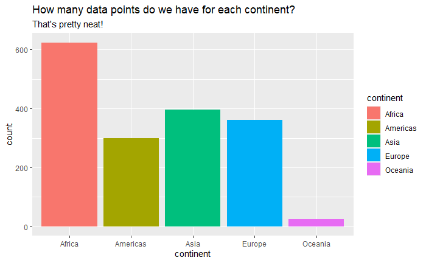

```r
ggplot(gm, aes(x = continent, fill = continent)) +
  geom_bar() +
  labs(title = "How many data points do we have for each continent?", subtitle = "That's pretty neat!")
```

```r
ls(pattern = '^geom_', env = as.environment('package:ggplot2'))
```

```
 [1] "geom_abline"            "geom_area"              "geom_bar"               "geom_bin2d"
 [5] "geom_blank"             "geom_boxplot"           "geom_col"               "geom_contour"
 [9] "geom_contour_filled"    "geom_count"             "geom_crossbar"          "geom_curve"
[13] "geom_density"           "geom_density_2d"        "geom_density_2d_filled" "geom_density2d"
[17] "geom_density2d_filled"  "geom_dotplot"           "geom_errorbar"          "geom_errorbarh"
[21] "geom_freqpoly"          "geom_function"          "geom_hex"               "geom_histogram"
[25] "geom_hline"             "geom_jitter"            "geom_label"             "geom_line"
[29] "geom_linerange"         "geom_map"               "geom_path"              "geom_point"
[33] "geom_pointrange"        "geom_polygon"           "geom_qq"                "geom_qq_line"
[37] "geom_quantile"          "geom_raster"            "geom_rect"              "geom_ribbon"
[41] "geom_rug"               "geom_segment"           "geom_sf"                "geom_sf_label"
[45] "geom_sf_text"           "geom_smooth"            "geom_spoke"             "geom_step"
[49] "geom_text"              "geom_tile"              "geom_violin"            "geom_vline"
```